# SPPH 504 Section 007 Lab (5.2) Propensity score matching in NHANES

Ehsan Karim, ehsan.karim@ubc.ca

01 May 2020

# 1 Pre-processing

## 1.1 load data

```r
load(file="data/analyticNHANES78.RData")
analytic.data <- DT9a
```

## 1.2 Set seed

```r
set.seed(123)
```

# 2 Zanutto E. L. (2006)

- “it is not necessary to use survey-weighted estimation for the propensity score model”

Propensity score analysis in 4 steps:

## 2.1 Step 1

Specify the propensity score model to estimate propensity scores

```r
ps.formula <- as.formula(I(arthritis.type==
                             "Rheumatoid arthritis") ~ gender+bmi+
                           diabetes+smoke+age+race+born+education+
                           marriage+annualincome+physical.activity+
                           medical.access+blood.pressure+healthy.diet+
                           covered.health)
```

## 2.2 Step 2

Match treated and untreated subjects on the estimated propensity scores

```r
require(MatchIt)
set.seed(123)
# This function fits propensity score model (using logistic
# regression as above) when specified distance = 'logit'
# performs nearest-neighbor (NN) matching,
# without replacement
# with caliper = .2*SD of propensity score
# within which to draw control units
# with 1:1 ratio (pair-matching)
match.obj <- matchit(ps.formula, data = analytic.data,
                     distance = 'logit',
                     method = "nearest",
                     replace=FALSE,
                     caliper = .2,
                     ratio = 1)
# see matchit function options here
# https://www.rdocumentation.org/packages/MatchIt/versions/1.0-1/topics/matchit
analytic.data$PS <- match.obj$distance
summary(match.obj$distance)
```

```
##     Min.  1st Qu.   Median     Mean  3rd Qu.     Max.
## 0.001637 0.014576 0.033560 0.064414 0.088187 0.652114
```

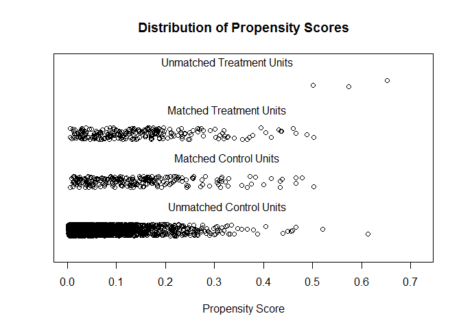

```
## [1] "To identify the units, use first mouse button; to stop, use second."
```

```
## integer(0)
```

```r
plot(match.obj, type = "jitter")
```

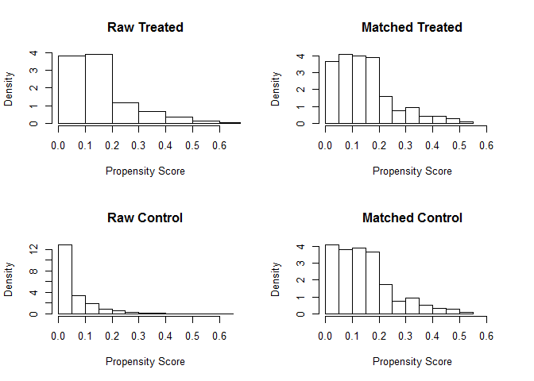

```r
plot(match.obj, type = "hist")
```

```r
tapply(analytic.data$PS, analytic.data$arthritis.type, summary)
```

```
## $`Non-arthritis`
##     Min.  1st Qu.   Median     Mean  3rd Qu.     Max.
## 0.001637 0.013800 0.030386 0.058382 0.076563 0.612251
##
## $`Rheumatoid arthritis`
##     Min.  1st Qu.   Median     Mean  3rd Qu.     Max.
## 0.006194 0.068167 0.128799 0.152026 0.193423 0.652114
```

```r
# check how many matched
match.obj
```

```
##
## Call:
## matchit(formula = ps.formula, data = analytic.data, method = "nearest",
##     distance = "logit", replace = FALSE, caliper = 0.2, ratio = 1)
##
## Sample sizes:
##           Control Treated
## All          3544     244
## Matched       241     241
## Unmatched    3303       3
## Discarded       0       0
```

```r
# extract matched data
matched.data <- match.data(match.obj)
```

## 2.3 Step 3

compare the similarity of baseline characteristics between treated and untreated subjects in a the propensity score-matched sample. In this case, we will compare SMD < 0.2 or not.

```r
require(tableone)
baselinevars <- c("gender", "bmi", "diabetes", "smoke", "age",
                "race", "born", "education", "marriage",
                "annualincome", "physical.activity", "medical.access",
                "blood.pressure", "healthy.diet", "covered.health")
tab1 <- CreateTableOne(strata = "arthritis.type", vars = baselinevars,
                       data = analytic.data, test = FALSE)
print(tab1, smd = TRUE)
```

```
##                           Stratified by arthritis.type
##                            Non-arthritis Rheumatoid arthritis SMD
##   n                        3544          244
##   gender = Female (%)      1713 (48.3)   137 (56.1)            0.157
##   bmi = (25,80] (%)        2430 (68.6)   182 (74.6)            0.134
##   diabetes = Yes (%)        298 ( 8.4)    28 (11.5)            0.103
##   smoke = Yes (%)          1549 (43.7)   135 (55.3)            0.234
##   age (%)                                                      0.826
##      (19.9,50]             2276 (64.2)    64 (26.2)
##      (50,70]                894 (25.2)   127 (52.0)
##      (70,81]                374 (10.6)    53 (21.7)
##   race (%)                                                     0.293
##      White                 1544 (43.6)    99 (40.6)
##      Black                  732 (20.7)    80 (32.8)
##      Other                 1268 (35.8)    65 (26.6)
##   born = USborn (%)        2570 (72.5)   197 (80.7)            0.195
##   education (%)                                                0.112
##      School                 396 (11.2)    32 (13.1)
##      College               1673 (47.2)   102 (41.8)
##      High.School           1475 (41.6)   110 (45.1)
##   marriage = Married (%)   2160 (60.9)   117 (48.0)            0.263
##   annualincome (%)                                             0.523
##      <20k                   698 (19.7)    98 (40.2)
##      20kto54k              1483 (41.8)    97 (39.8)
##      55k+                  1363 (38.5)    49 (20.1)
##   physical.activity (%)                                        0.275
##      No                    1971 (55.6)   166 (68.0)
##      High                   768 (21.7)    32 (13.1)
##      Moderate               805 (22.7)    46 (18.9)
##   medical.access = Yes (%) 2882 (81.3)   232 (95.1)            0.437
##   blood.pressure = Yes (%)  919 (25.9)   138 (56.6)            0.655
##   healthy.diet (%)                                             0.167
##      Poor                   193 ( 5.4)    23 ( 9.4)
##      Fair                   819 (23.1)    61 (25.0)
##      Good                  2532 (71.4)   160 (65.6)
##   covered.health = Yes (%) 2522 (71.2)   207 (84.8)            0.335
```

```r
tab1m <- CreateTableOne(strata = "arthritis.type", vars = baselinevars,
                        data = matched.data, test = FALSE)
print(tab1m, smd = TRUE)
```

```
##                           Stratified by arthritis.type
##                            Non-arthritis Rheumatoid arthritis SMD
##   n                        241           241
##   gender = Female (%)      131 (54.4)    134 (55.6)            0.025
##   bmi = (25,80] (%)        172 (71.4)    180 (74.7)            0.075
##   diabetes = Yes (%)        27 (11.2)     28 (11.6)            0.013
##   smoke = Yes (%)          135 (56.0)    132 (54.8)            0.025
##   age (%)                                                      0.117
##      (19.9,50]              73 (30.3)     64 (26.6)
##      (50,70]               125 (51.9)    124 (51.5)
##      (70,81]                43 (17.8)     53 (22.0)
##   race (%)                                                     0.103
##      White                  98 (40.7)     99 (41.1)
##      Black                  68 (28.2)     77 (32.0)
##      Other                  75 (31.1)     65 (27.0)
##   born = USborn (%)        198 (82.2)    194 (80.5)            0.043
##   education (%)                                                0.086
##      School                 28 (11.6)     32 (13.3)
##      College                96 (39.8)    102 (42.3)
##      High.School           117 (48.5)    107 (44.4)
##   marriage = Married (%)   124 (51.5)    117 (48.5)            0.058
##   annualincome (%)                                             0.017
##      <20k                   97 (40.2)     95 (39.4)
##      20kto54k               96 (39.8)     97 (40.2)
##      55k+                   48 (19.9)     49 (20.3)
##   physical.activity (%)                                        0.116
##      No                    156 (64.7)    163 (67.6)
##      High                   42 (17.4)     32 (13.3)
##      Moderate               43 (17.8)     46 (19.1)
##   medical.access = Yes (%) 230 (95.4)    229 (95.0)            0.019
##   blood.pressure = Yes (%) 137 (56.8)    135 (56.0)            0.017
##   healthy.diet (%)                                             0.069
##      Poor                   19 ( 7.9)     21 ( 8.7)
##      Fair                   67 (27.8)     60 (24.9)
##      Good                  155 (64.3)    160 (66.4)
##   covered.health = Yes (%) 202 (83.8)    205 (85.1)            0.034
```

## 2.4 Step 4

Estimate the effect of treatment on outcomes using propensity score-matched sample

- “it is important to incorporate the survey design in both linear regression and propensity score analysis. Ignoring the survey weights affects the estimates of population-level effects substantially”

```r
require(survey)
# setup the design with survey features
design.set <- svydesign(strata=~strata, id=~PSU,
                        weights=~interview.weight, data=matched.data, nest=TRUE)
out.formula <- as.formula(I(heart.attack=="Yes") ~ arthritis.type)
sfit <- svyglm(out.formula,family=quasibinomial, design = design.set)
require(jtools)
summ(sfit, exp = TRUE, confint = TRUE)
```

| Observations | 482 |
| --- | --- |
| Dependent variable | I(heart.attack == “Yes”) |
| Type | Survey-weighted generalized linear model |
| Family | quasibinomial |
| Link | logit |

| Pseudo-R² (Cragg-Uhler) | 0.00 |
| --- | --- |
| Pseudo-R² (McFadden) | 0.00 |
| AIC | NA |

|  | exp(Est.) | 2.5% | 97.5% | t val. | p |
| --- | --- | --- | --- | --- | --- |
| (Intercept) | 0.08 | 0.04 | 0.17 | -6.44 | 0.00 |
| arthritis.typeRheumatoid arthritis | 0.94 | 0.30 | 2.94 | -0.11 | 0.91 |

Standard errors: Robust

## 2.5 More refined analysis

Note that, in the matched data, if are variables where SMDs were $>$ .2, we need to repeat the steps 1-3 untill we are satisfied with the SMDs.

```r
design.set <- svydesign(strata=~strata, id=~PSU,
                        weights=~interview.weight, data=matched.data, nest=TRUE)
out.formula <- as.formula(I(heart.attack=="Yes") ~ arthritis.type+
                            age+medical.access+blood.pressure+healthy.diet+covered.health)
sfit <- svyglm(out.formula,family=quasibinomial, design = design.set)
require(jtools)
summ(sfit, exp = TRUE, confint = TRUE)
```

| Observations | 482 |
| --- | --- |
| Dependent variable | I(heart.attack == “Yes”) |
| Type | Survey-weighted generalized linear model |
| Family | quasibinomial |
| Link | logit |

| Pseudo-R² (Cragg-Uhler) | 0.05 |
| --- | --- |
| Pseudo-R² (McFadden) | 0.09 |
| AIC | NA |

|  | exp(Est.) | 2.5% | 97.5% | t val. | p |
| --- | --- | --- | --- | --- | --- |
| (Intercept) | 0.03 | 0.00 | 0.25 | -3.21 | 0.01 |
| arthritis.typeRheumatoid arthritis | 0.88 | 0.36 | 2.15 | -0.29 | 0.78 |
| age(50,70] | 1.23 | 0.29 | 5.25 | 0.28 | 0.79 |
| age(70,81] | 2.35 | 0.90 | 6.15 | 1.75 | 0.12 |
| medical.accessYes | 0.75 | 0.08 | 6.65 | -0.26 | 0.80 |
| blood.pressureYes | 5.98 | 1.73 | 20.67 | 2.82 | 0.02 |
| healthy.dietFair | 1.26 | 0.26 | 6.18 | 0.29 | 0.78 |
| healthy.dietGood | 1.27 | 0.26 | 6.14 | 0.30 | 0.77 |
| covered.healthYes | 0.62 | 0.11 | 3.46 | -0.55 | 0.60 |

Standard errors: Robust

# 3 DuGoff, E. H., Schuler, M., & Stuart, E. A. (2014).

Propensity score analysis in 4 steps (PATT)

## 3.1 Step 1

Specify the propensity score model to estimate propensity scores

```r
# response = exposure variable
# independent variables = baseline covariates
ps.formula <- as.formula(I(arthritis.type==
                             "Rheumatoid arthritis") ~ gender+bmi+
                           diabetes+smoke+age+race+born+education+
                           marriage+annualincome+physical.activity+
                           medical.access+blood.pressure+healthy.diet+
                           covered.health+
                           PSU+strata+interview.weight)
```

## 3.2 Step 2

Match treated and untreated subjects on the estimated propensity scores

```r
require(MatchIt)
set.seed(123)
# This function fits propensity score model (using logistic
# regression as above) when specified distance = 'logit'
# performs nearest-neighbor (NN) matching,
# without replacement
# with caliper = .2*SD of propensity score
# within which to draw control units
# with 1:1 ratio (pair-matching)
match.obj <- matchit(ps.formula, data = analytic.data,
                     distance = 'logit',
                     method = "nearest",
                     replace=FALSE,
                     caliper = .2,
                     ratio = 1)
analytic.data$PS <- match.obj$distance
summary(match.obj$distance)
```

```
##     Min.  1st Qu.   Median     Mean  3rd Qu.     Max.
## 0.001373 0.014070 0.032528 0.064414 0.087050 0.618220
```

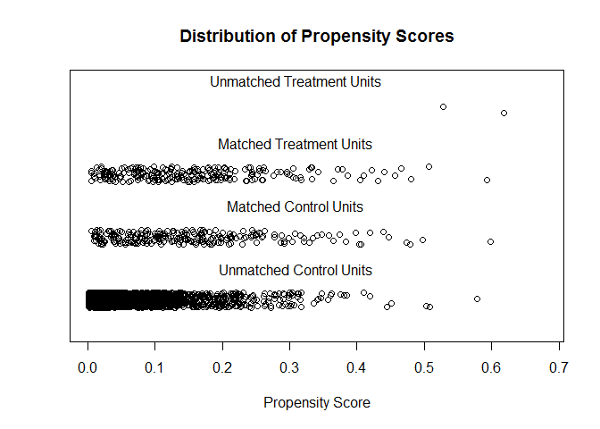

```
## [1] "To identify the units, use first mouse button; to stop, use second."
```

```
## integer(0)
```

```r
plot(match.obj, type = "jitter")
```

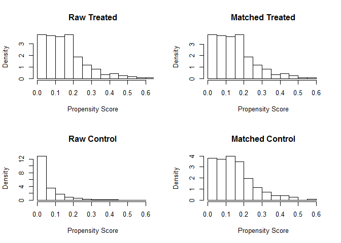

```r
plot(match.obj, type = "hist")
```

```r
tapply(analytic.data$PS, analytic.data$arthritis.type, summary)
```

```
## $`Non-arthritis`
##     Min.  1st Qu.   Median     Mean  3rd Qu.     Max.
## 0.001373 0.013465 0.029988 0.058206 0.075126 0.597606
##
## $`Rheumatoid arthritis`
##     Min.  1st Qu.   Median     Mean  3rd Qu.     Max.
## 0.005355 0.072551 0.132798 0.154578 0.203229 0.618220
```

```r
# check how many matched
match.obj
```

```
##
## Call:
## matchit(formula = ps.formula, data = analytic.data, method = "nearest",
##     distance = "logit", replace = FALSE, caliper = 0.2, ratio = 1)
##
## Sample sizes:
##           Control Treated
## All          3544     244
## Matched       242     242
## Unmatched    3302       2
## Discarded       0       0
```

```r
# extract matched data
matched.data <- match.data(match.obj)
```

## 3.3 Step 3

Compare the similarity of baseline characteristics between treated and untreated subjects in a the propensity score-matched sample. In this case, we will compare SMD < 0.2 or not.

```r
require(tableone)
baselinevars <- c("gender", "bmi", "diabetes", "smoke", "age",
                "race", "born", "education", "marriage",
                "annualincome", "physical.activity", "medical.access",
                "blood.pressure", "healthy.diet", "covered.health",
                "interview.weight", "PSU", "strata")
matched.data$interview.weight <- as.numeric(as.character(matched.data$interview.weight))
matched.data$strata <- as.numeric(as.character(matched.data$strata))
tab1m <- CreateTableOne(strata = "arthritis.type", vars = baselinevars,
                        data = matched.data, test = FALSE)
print(tab1m, smd = TRUE)
```

```
##                               Stratified by arthritis.type
##                                Non-arthritis       Rheumatoid arthritis SMD
##   n                                 242                 242
##   gender = Female (%)               132 (54.5)          135 (55.8)       0.025
##   bmi = (25,80] (%)                 178 (73.6)          181 (74.8)       0.028
##   diabetes = Yes (%)                 30 (12.4)           28 (11.6)       0.025
##   smoke = Yes (%)                   145 (59.9)          133 (55.0)       0.100
##   age (%)                                                                0.031
##      (19.9,50]                       62 (25.6)           64 (26.4)
##      (50,70]                        124 (51.2)          125 (51.7)
##      (70,81]                         56 (23.1)           53 (21.9)
##   race (%)                                                               0.110
##      White                           94 (38.8)           99 (40.9)
##      Black                           71 (29.3)           78 (32.2)
##      Other                           77 (31.8)           65 (26.9)
##   born = USborn (%)                 184 (76.0)          195 (80.6)       0.110
##   education (%)                                                          0.090
##      School                          38 (15.7)           32 (13.2)
##      College                         93 (38.4)          102 (42.1)
##      High.School                    111 (45.9)          108 (44.6)
##   marriage = Married (%)            123 (50.8)          117 (48.3)       0.050
##   annualincome (%)                                                       0.011
##      <20k                            96 (39.7)           96 (39.7)
##      20kto54k                        98 (40.5)           97 (40.1)
##      55k+                            48 (19.8)           49 (20.2)
##   physical.activity (%)                                                  0.057
##      No                             158 (65.3)          164 (67.8)
##      High                            36 (14.9)           32 (13.2)
##      Moderate                        48 (19.8)           46 (19.0)
##   medical.access = Yes (%)          229 (94.6)          230 (95.0)       0.019
##   blood.pressure = Yes (%)          137 (56.6)          136 (56.2)       0.008
##   healthy.diet (%)                                                       0.038
##      Poor                            21 ( 8.7)           21 ( 8.7)
##      Fair                            65 (26.9)           61 (25.2)
##      Good                           156 (64.5)          160 (66.1)
##   covered.health = Yes (%)          205 (84.7)          206 (85.1)       0.012
##   interview.weight (mean (SD)) 25635.59 (21803.53) 26871.01 (24800.23)   0.053
##   PSU (mean (SD))                  1.57 (0.50)         1.53 (0.50)       0.066
##   strata (mean (SD))              65.07 (4.45)        65.49 (4.23)       0.097
```

## 3.4 Step 4

Estimate the effect of treatment on outcomes using propensity score-matched sample

```r
require(survey)
# setup the design with survey features
# adjust for potentially imbalanced covariates
design.set <- svydesign(strata=~strata, id=~PSU,
                        weights=~interview.weight, data=matched.data, nest=TRUE)
out.formula <- as.formula(I(heart.attack=="Yes") ~ arthritis.type+annualincome)
sfit <- svyglm(out.formula,family=quasibinomial, design = design.set)
require(jtools)
summ(sfit, exp = TRUE, confint = TRUE)
```

| Observations | 484 |
| --- | --- |
| Dependent variable | I(heart.attack == “Yes”) |
| Type | Survey-weighted generalized linear model |
| Family | quasibinomial |
| Link | logit |

| Pseudo-R² (Cragg-Uhler) | 0.06 |
| --- | --- |
| Pseudo-R² (McFadden) | 0.10 |
| AIC | NA |

|  | exp(Est.) | 2.5% | 97.5% | t val. | p |
| --- | --- | --- | --- | --- | --- |
| (Intercept) | 0.12 | 0.06 | 0.26 | -5.53 | 0.00 |
| arthritis.typeRheumatoid arthritis | 1.39 | 0.62 | 3.13 | 0.79 | 0.44 |
| annualincome20kto54k | 0.27 | 0.10 | 0.74 | -2.56 | 0.02 |
| annualincome55k+ | 0.07 | 0.01 | 0.37 | -3.17 | 0.01 |

Standard errors: Robust

## 3.5 More refined analysis

Note that, in the matched data, if are variables where SMDs were $>$ .2, we need to repeat the steps 1-3 untill we are satisfied with the SMDs.

```r
design.set <- svydesign(strata=~strata, id=~PSU,
                        weights=~interview.weight, data=matched.data, nest=TRUE)
out.formula <- as.formula(I(heart.attack=="Yes") ~ arthritis.type+
                            smoke+born+education+annualincome+healthy.diet)
sfit <- svyglm(out.formula,family=quasibinomial, design = design.set)
summ(sfit, exp = TRUE, confint = TRUE)
```

| Observations | 484 |
| --- | --- |
| Dependent variable | I(heart.attack == “Yes”) |
| Type | Survey-weighted generalized linear model |
| Family | quasibinomial |
| Link | logit |

| Pseudo-R² (Cragg-Uhler) | 0.09 |
| --- | --- |
| Pseudo-R² (McFadden) | 0.14 |
| AIC | NA |

|  | exp(Est.) | 2.5% | 97.5% | t val. | p |
| --- | --- | --- | --- | --- | --- |
| (Intercept) | 0.03 | 0.01 | 0.13 | -4.46 | 0.00 |
| arthritis.typeRheumatoid arthritis | 1.36 | 0.56 | 3.26 | 0.68 | 0.52 |
| smokeYes | 3.63 | 1.21 | 10.89 | 2.30 | 0.06 |
| bornUSborn | 2.37 | 1.09 | 5.14 | 2.19 | 0.06 |
| educationCollege | 0.96 | 0.32 | 2.87 | -0.07 | 0.94 |
| educationHigh.School | 0.75 | 0.21 | 2.68 | -0.45 | 0.67 |
| annualincome20kto54k | 0.25 | 0.09 | 0.74 | -2.52 | 0.04 |
| annualincome55k+ | 0.08 | 0.02 | 0.41 | -3.07 | 0.02 |
| healthy.dietFair | 0.79 | 0.22 | 2.86 | -0.36 | 0.73 |
| healthy.dietGood | 1.10 | 0.32 | 3.76 | 0.15 | 0.88 |

Standard errors: Robust

# 4 Austin P. C., Jembere N. and Chiu M. (2018).

Propensity score analysis in 4 steps (PATT)

## 4.1 Step 1

Specify the propensity score model to estimate propensity scores

```r
# response = exposure variable
# independent variables = baseline covariates
ps.formula <- as.formula(I(arthritis.type==
                             "Rheumatoid arthritis") ~ gender+bmi+
                           diabetes+smoke+age+race+born+education+
                           marriage+annualincome+physical.activity+
                           medical.access+blood.pressure+healthy.diet+
                           covered.health)
require(survey)
analytic.design <- svydesign(id=~PSU,weights=~interview.weight,
                             strata=~strata,
                             data=analytic.data, nest=TRUE)
ps.fit <- svyglm(ps.formula, design=analytic.design, family=quasibinomial)
analytic.data$PS <- fitted(ps.fit)


analytic.data$heart.attack2 <- ifelse(analytic.data$heart.attack ==
                                        "Yes", 1, 0)
analytic.data$arthritis.type2 <- ifelse(analytic.data$arthritis.type ==
                                          "Rheumatoid arthritis", 1, 0)
```

## 4.2 Step 2

Match treated and untreated subjects on the estimated propensity scores

```r
require(Matching)
match.obj2 <- Match(Y=analytic.data$heart.attack2,
                    Tr=analytic.data$arthritis.type2,
                    X=analytic.data$PS,
                    M=1,
                    estimand = "ATT",
                    replace=FALSE,
                    caliper = 0.2)
summary(match.obj2)
```

```
##
## Estimate...  0.024691
## SE.........  0.021718
## T-stat.....  1.1369
## p.val......  0.25558
##
## Original number of observations..............  3788
## Original number of treated obs...............  244
## Matched number of observations...............  243
## Matched number of observations  (unweighted).  243
##
## Caliper (SDs)........................................   0.2
## Number of obs dropped by 'exact' or 'caliper'  1
```

```r
matched.data2 <- analytic.data[c(match.obj2$index.treated,
                                 match.obj2$index.control),]
```

## 4.3 Step 3

Compare the similarity of baseline characteristics between treated and untreated subjects in a the propensity score-matched sample. In this case, we will compare SMD < 0.2 or not.

```r
require(survey)
baselinevars <- c("gender", "bmi", "diabetes", "smoke", "age",
                "race", "born", "education", "marriage",
                "annualincome", "physical.activity", "medical.access",
                "blood.pressure", "healthy.diet", "covered.health")
analytic.design <- svydesign(id=~PSU,weights=~interview.weight,
                             strata=~strata,
                             data=matched.data2, nest=TRUE)
tab1m <- svyCreateTableOne(strata = "arthritis.type",
                           vars = baselinevars,
                           data = analytic.design, test = FALSE)
print(tab1m, smd = TRUE)
```

```
##                           Stratified by arthritis.type
##                            Non-arthritis     Rheumatoid arthritis SMD
##   n                        7841075.2         6516653.1
##   gender = Female (%)      4414439.4 (56.3)  3788834.0 (58.1)      0.037
##   bmi = (25,80] (%)        6307102.6 (80.4)  5213690.4 (80.0)      0.011
##   diabetes = Yes (%)        715605.4 ( 9.1)   589128.3 ( 9.0)      0.003
##   smoke = Yes (%)          3936990.9 (50.2)  3357917.3 (51.5)      0.026
##   age (%)                                                          0.090
##      (19.9,50]             3356580.4 (42.8)  2769791.7 (42.5)
##      (50,70]               3478642.7 (44.4)  2713472.1 (41.6)
##      (70,81]               1005852.1 (12.8)  1033389.3 (15.9)
##   race (%)                                                         0.100
##      White                 5576860.6 (71.1)  4434100.5 (68.0)
##      Black                 1150803.6 (14.7)  1197838.0 (18.4)
##      Other                 1113411.0 (14.2)   884714.5 (13.6)
##   born = USborn (%)        7005291.6 (89.3)  5849133.8 (89.8)      0.014
##   education (%)                                                    0.099
##      School                 562949.7 ( 7.2)   529421.9 ( 8.1)
##      College               3665577.8 (46.7)  3302838.0 (50.7)
##      High.School           3612547.8 (46.1)  2684393.2 (41.2)
##   marriage = Married (%)   4309879.2 (55.0)  3576055.0 (54.9)      0.002
##   annualincome (%)                                                 0.080
##      <20k                  2200580.2 (28.1)  2051603.0 (31.5)
##      20kto54k              3372740.3 (43.0)  2596796.9 (39.8)
##      55k+                  2267754.7 (28.9)  1868253.2 (28.7)
##   physical.activity (%)                                            0.084
##      No                    4548878.9 (58.0)  3970869.5 (60.9)
##      High                  1161998.0 (14.8)  1014480.1 (15.6)
##      Moderate              2130198.3 (27.2)  1531303.5 (23.5)
##   medical.access = Yes (%) 7489231.7 (95.5)  6269516.7 (96.2)      0.035
##   blood.pressure = Yes (%) 3891328.5 (49.6)  3477742.6 (53.4)      0.075
##   healthy.diet (%)                                                 0.027
##      Poor                   830551.5 (10.6)   732368.4 (11.2)
##      Fair                  1863483.5 (23.8)  1489982.7 (22.9)
##      Good                  5147040.3 (65.6)  4294302.1 (65.9)
##   covered.health = Yes (%) 7021687.7 (89.6)  5597777.0 (85.9)      0.111
```

## 4.4 Step 4

Estimate the effect of treatment on outcomes using propensity score-matched sample.

```r
require(survey)
# setup the design with survey features
# adjust for potentially imbalanced covariates
out.formula <- as.formula(I(heart.attack=="Yes") ~ arthritis.type+
                            smoke+race+annualincome+
                            physical.activity+healthy.diet)
sfit <- svyglm(out.formula,family=quasibinomial, design = analytic.design)
require(jtools)
summ(sfit, exp = TRUE, confint = TRUE)
```

| Observations | 486 |
| --- | --- |
| Dependent variable | I(heart.attack == “Yes”) |
| Type | Survey-weighted generalized linear model |
| Family | quasibinomial |
| Link | logit |

| Pseudo-R² (Cragg-Uhler) | 0.07 |
| --- | --- |
| Pseudo-R² (McFadden) | 0.11 |
| AIC | NA |

|  | exp(Est.) | 2.5% | 97.5% | t val. | p |
| --- | --- | --- | --- | --- | --- |
| (Intercept) | 0.02 | 0.00 | 0.17 | -3.80 | 0.01 |
| arthritis.typeRheumatoid arthritis | 1.41 | 0.50 | 4.00 | 0.65 | 0.54 |
| smokeYes | 2.93 | 0.70 | 12.30 | 1.47 | 0.19 |
| raceBlack | 2.06 | 1.10 | 3.82 | 2.28 | 0.06 |
| raceOther | 2.06 | 0.90 | 4.71 | 1.70 | 0.14 |
| annualincome20kto54k | 0.57 | 0.19 | 1.74 | -0.98 | 0.36 |
| annualincome55k+ | 0.33 | 0.09 | 1.24 | -1.64 | 0.15 |
| physical.activityHigh | 1.04 | 0.47 | 2.31 | 0.09 | 0.93 |
| physical.activityModerate | 0.55 | 0.20 | 1.48 | -1.18 | 0.28 |
| healthy.dietFair | 0.56 | 0.12 | 2.64 | -0.74 | 0.49 |
| healthy.dietGood | 1.63 | 0.59 | 4.52 | 0.94 | 0.38 |

Standard errors: Robust

## 4.5 More refined analysis

Note that, in the matched data, if are variables where SMDs were $>$ .2, we need to repeat the steps 1-3 untill we are satisfied with the SMDs.

```r
design.set <- svydesign(strata=~strata, id=~PSU,
                        weights=~interview.weight, data=matched.data, nest=TRUE)
out.formula <- as.formula(I(heart.attack=="Yes") ~ arthritis.type+
                            race + annualincome + physical.activity + healthy.diet)
sfit <- svyglm(out.formula,family=quasibinomial, design = analytic.design)
summ(sfit, exp = TRUE, confint = TRUE)
```

| Observations | 486 |
| --- | --- |
| Dependent variable | I(heart.attack == “Yes”) |
| Type | Survey-weighted generalized linear model |
| Family | quasibinomial |
| Link | logit |

| Pseudo-R² (Cragg-Uhler) | 0.05 |
| --- | --- |
| Pseudo-R² (McFadden) | 0.08 |
| AIC | NA |

|  | exp(Est.) | 2.5% | 97.5% | t val. | p |
| --- | --- | --- | --- | --- | --- |
| (Intercept) | 0.06 | 0.01 | 0.31 | -3.32 | 0.01 |
| arthritis.typeRheumatoid arthritis | 1.46 | 0.53 | 4.03 | 0.73 | 0.49 |
| raceBlack | 2.09 | 1.15 | 3.80 | 2.42 | 0.05 |
| raceOther | 1.84 | 0.80 | 4.23 | 1.43 | 0.19 |
| annualincome20kto54k | 0.54 | 0.18 | 1.61 | -1.10 | 0.31 |
| annualincome55k+ | 0.26 | 0.08 | 0.79 | -2.37 | 0.05 |
| physical.activityHigh | 1.08 | 0.44 | 2.65 | 0.16 | 0.88 |
| physical.activityModerate | 0.50 | 0.18 | 1.35 | -1.37 | 0.21 |
| healthy.dietFair | 0.52 | 0.11 | 2.48 | -0.83 | 0.44 |
| healthy.dietGood | 1.51 | 0.50 | 4.54 | 0.74 | 0.49 |

Standard errors: Robust